# Basic Data Analysis

The dataset covers supplement sales in Canada, the United States, and the United Kingdom. It contains information on 16 different supplements, including category, price, units sold, units returned, discounts, and total revenue.

The records span a period from January 6, 2020, to March 31, 2025.

Three stores are represented: Walmart, iHerb, and Amazon.

**The currency used in the data is unspecified.**

|  | Date | Product Name | Category | Units Sold | Price | Revenue | Discount | Units Returned | Location | Platform |
| --- | --- | --- | --- | --- | --- | --- | --- | --- | --- | --- |
| 4015 | 2024-10-21 | Electrolyte Powder | Hydration | 148 | 31.45 | 4654.60 | 0.18 | 3 | Canada | iHerb |
| 2070 | 2022-06-27 | Creatine | Performance | 156 | 34.40 | 5366.40 | 0.05 | 3 | USA | Walmart |
| 3567 | 2024-04-08 | Electrolyte Powder | Hydration | 152 | 47.13 | 7163.76 | 0.13 | 0 | USA | Walmart |
| 3338 | 2024-01-01 | Ashwagandha | Herbal | 172 | 15.23 | 2619.56 | 0.05 | 7 | Canada | Walmart |
| 2970 | 2023-07-24 | Ashwagandha | Herbal | 155 | 37.67 | 5838.85 | 0.02 | 2 | Canada | iHerb |
| 4378 | 2025-03-31 | Ashwagandha | Herbal | 145 | 58.08 | 8421.60 | 0.24 | 2 | Canada | Amazon |
| 2018 | 2022-06-06 | Fish Oil | Omega | 157 | 20.63 | 3238.91 | 0.09 | 1 | USA | iHerb |
| 640 | 2020-10-12 | Whey Protein | Protein | 131 | 58.18 | 7621.58 | 0.09 | 1 | USA | Walmart |
| 279 | 2020-05-04 | Zinc | Mineral | 154 | 43.68 | 6726.72 | 0.04 | 2 | Canada | iHerb |
| 3987 | 2024-10-14 | Multivitamin | Vitamin | 150 | 14.73 | 2209.50 | 0.07 | 3 | Canada | iHerb |

```
Date               274
Product Name        16
Category            10
Units Sold          81
Price             2919
Revenue           4326
Discount            26
Units Returned       9
Location             3
Platform             3
dtype: int64
```

# Missing Values

```
Date              0
Product Name      0
Category          0
Units Sold        0
Price             0
Revenue           0
Discount          0
Units Returned    0
Location          0
Platform          0
dtype: int64
```

The dataset is fully complete, with no missing values, so data quality is not a concern.

# Column Analysis

[interactive chart not shown]

```
Category
Vitamin        822
Mineral        822
Protein        548
Performance    548
Omega          274
Amino Acid     274
Herbal         274
Sleep Aid      274
Fat Burner     274
Hydration      274
Name: count, dtype: int64
```

```
Product Name
Whey Protein          274
Vitamin C             274
Fish Oil              274
Multivitamin          274
Pre-Workout           274
BCAA                  274
Creatine              274
Zinc                  274
Collagen Peptides     274
Magnesium             274
Ashwagandha           274
Melatonin             274
Biotin                274
Green Tea Extract     274
Iron Supplement       274
Electrolyte Powder    274
Name: count, dtype: int64
```

Each product has the same number of records, though vitamins and minerals dominate the dataset..

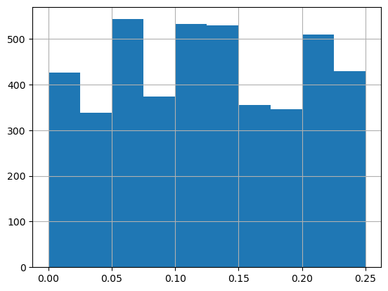

Discounts range from 0% to 25%.

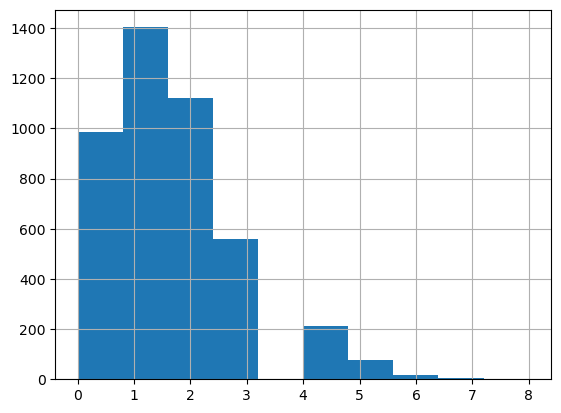

Returns are relatively rare, averaging 1–2 per week, and only occasionally exceeding 4.

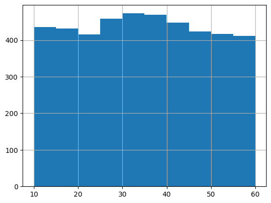

Product prices range from 10 to 60 (currency unspecified).

# Transformations for Further Analysis

The following derived columns were calculated to enrich the analysis:

- Return Rate – measures how often a product is returned, indicating product quality or potential issues.
- Revenue per Unit – the average selling price per item, highlighting profit margins.
- Units Sold STD – standard deviation of units sold, where a lower value indicates stable sales and lower risk.
- Normalized columns *_norm* – created to allow for more precise scoring.
- Score – a composite metric based on revenue, sales stability, and returns, designed to identify products with the highest earning potential at the lowest risk.

# Correlations

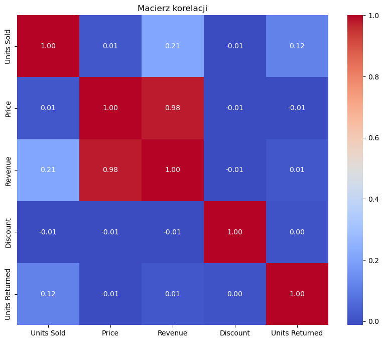

The most notable correlation shows that higher product prices are strongly associated with higher revenue. This suggests that, at least for supplements, customers may associate higher prices with higher quality and be willing to pay more.

This insight opens the possibility of slightly increasing prices for lower-performing products to test whether sales improve under the perception of greater quality.

| Product Name | Units Sold | Revenue | Discount | Units Returned | Return Rate | Revenue per Unit | Units Sold STD | Revenue_norm | Units Sold STD_norm | Return Rate_norm | Score |
| --- | --- | --- | --- | --- | --- | --- | --- | --- | --- | --- | --- |
| Zinc | 41204 | 1482546.95 | 0.13 | 394 | 0.01 | 35.98 | 11.61 | 0.97 | 1.00 | 0.94 | 0.97 |
| BCAA | 41027 | 1464819.63 | 0.12 | 428 | 0.01 | 35.70 | 11.66 | 0.82 | 0.96 | 0.41 | 0.78 |
| Biotin | 41533 | 1486798.62 | 0.12 | 411 | 0.01 | 35.80 | 12.66 | 1.00 | 0.22 | 0.72 | 0.71 |
| Whey Protein | 41264 | 1422194.85 | 0.12 | 409 | 0.01 | 34.47 | 12.02 | 0.48 | 0.68 | 0.71 | 0.59 |
| Melatonin | 41165 | 1397315.79 | 0.12 | 408 | 0.01 | 33.94 | 11.64 | 0.28 | 0.98 | 0.71 | 0.58 |
| Pre-Workout | 41287 | 1477183.78 | 0.13 | 426 | 0.01 | 35.78 | 12.89 | 0.92 | 0.06 | 0.47 | 0.57 |
| Collagen Peptides | 40856 | 1433297.24 | 0.12 | 427 | 0.01 | 35.08 | 12.01 | 0.57 | 0.68 | 0.40 | 0.57 |
| Green Tea Extract | 40743 | 1440900.05 | 0.13 | 417 | 0.01 | 35.37 | 12.37 | 0.63 | 0.42 | 0.52 | 0.55 |
| Creatine | 41236 | 1432518.40 | 0.12 | 415 | 0.01 | 34.74 | 12.39 | 0.57 | 0.41 | 0.62 | 0.53 |
| Electrolyte Powder | 41065 | 1411951.38 | 0.12 | 441 | 0.01 | 34.38 | 11.70 | 0.40 | 0.93 | 0.24 | 0.53 |
| Fish Oil | 41325 | 1451065.87 | 0.13 | 407 | 0.01 | 35.11 | 12.89 | 0.71 | 0.06 | 0.75 | 0.53 |
| Ashwagandha | 41408 | 1405700.79 | 0.13 | 392 | 0.01 | 33.95 | 12.87 | 0.35 | 0.08 | 1.00 | 0.40 |
| Iron Supplement | 41194 | 1431582.41 | 0.12 | 426 | 0.01 | 34.75 | 12.97 | 0.56 | 0.01 | 0.46 | 0.37 |
| Vitamin C | 40727 | 1421998.07 | 0.13 | 457 | 0.01 | 34.92 | 12.77 | 0.48 | 0.14 | 0.00 | 0.28 |
| Multivitamin | 41174 | 1391427.99 | 0.13 | 425 | 0.01 | 33.79 | 12.99 | 0.24 | 0.00 | 0.47 | 0.21 |
| Magnesium | 41270 | 1361978.63 | 0.13 | 431 | 0.01 | 33.00 | 12.67 | 0.00 | 0.21 | 0.40 | 0.14 |

- Zinc – often used for acne, hair, and nail health.
- BCAA (Branched-Chain Amino Acids) – popular for muscle recovery.
- Biotin – improves skin, hair, and nail health.

Many supplements in the dataset contribute to appearance and beauty-related benefits, even if not always immediately obvious. For example, Vitamin C helps prevent dental issues, which could be highlighted in promotions, as customers are often motivated by improvements to external appearance.

The earlier correlation between price and revenue also suggests that subtle price increases on lower-performing products would likely go unnoticed in the short term but could lead to significant gains over several years.

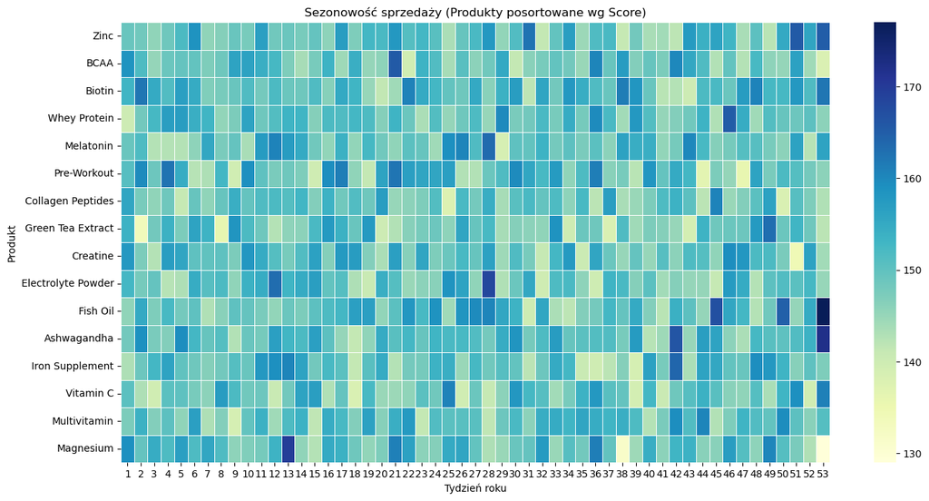

The above chart illustrates the number of products sold on a week-by-week basis. It provides an indication of seasonal demand patterns, showing what level of sales can generally be expected in different months.

# Outliers

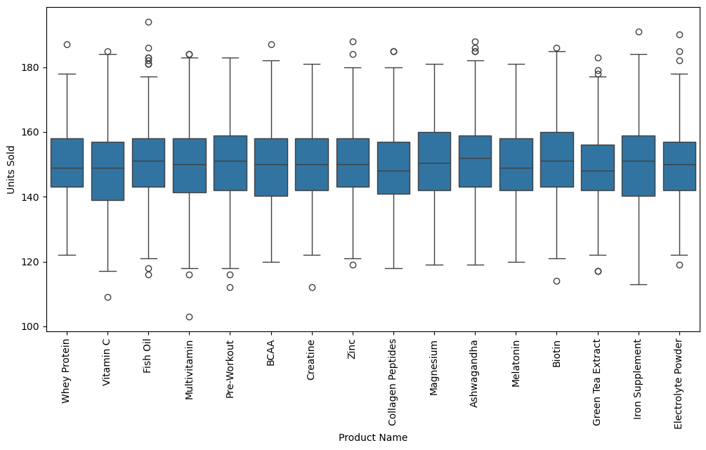

A few outliers exist in weekly sales, but they are rare and likely reflect normal market variability.

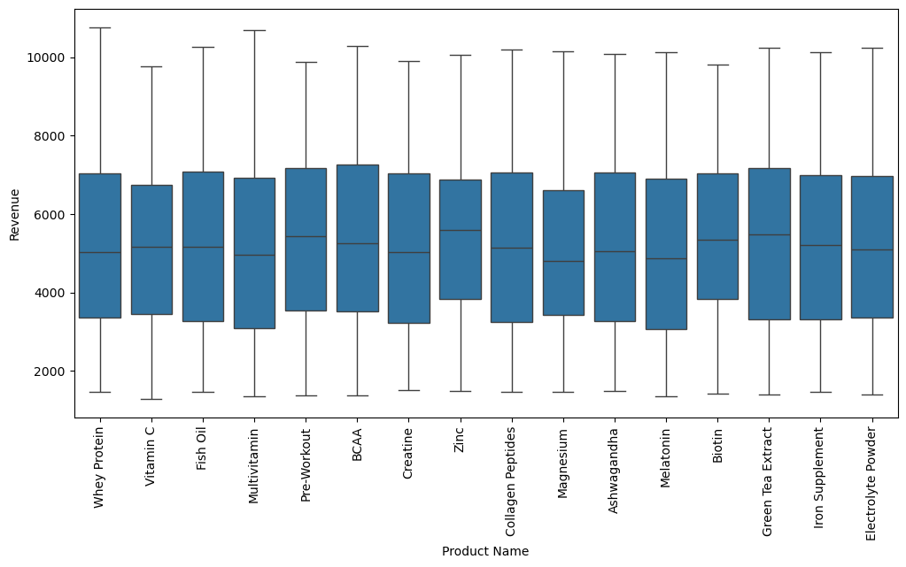

No major anomalies are observed in total revenue.

# Summary & Recommendations

This dataset tracks the sales of 16 supplements over a five-year period. Based on the analysis, the following experiments are recommended:

- Marketing Strategy: Emphasize the appearance-enhancing benefits of supplements (e.g., skin, hair, nails, dental health) in advertising campaigns.
- Pricing Strategy: Implement small, controlled price increases on lower-revenue products to test whether customers respond positively to perceived higher quality.